# KTH Project Data with Rill Developer

2023-08-15

## Agenda

- Recall and Review
- Relational data table (kopplingstabell)
- Rill Developer (Demo)
  - Concept
  - How it can be leveraged to answer project-related questions.

## Recall and Review

- “**Which projects are active? Which researchers are involved? From which organisations? Grant sizes?**
- **What we have accomplished so far:**
- Accessed and collected data via APIs
- Mobilized data for KTH projects using Object Storage (S3)
- Conducted Exploratory Data Analysis & String Matching:

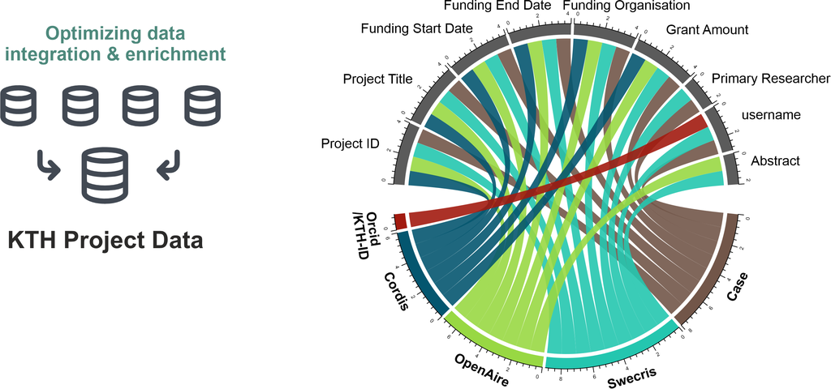

## KTH Project Data Sources

- Data records as of 2023-08-21
- [Check out our landing site](https://bibliometrics.lib.kth.se/RI_sources_KTH.html)

[output not shown]

## Relational data table

- Method — Approximate and exact string matching but also probabilistic record linkage
- Strength — jaro-winkler similarity index
- Usage — multi-purpose use e.g., enrich and harvest data from other sources

|  | from | from_id | to | to_id | strength | curated | date |
| --- | --- | --- | --- | --- | --- | --- | --- |
| 1 | case | RESPROJ-0000048 | swecris | 2018-04496_Vinnova | 1 |  | 2023-08-27 |
| 2 | case | RESPROJ-0000049 | swecris | 2018-04681_Vinnova | 1 |  | 2023-08-27 |

## Rill developer

Rill Developer https://www.rilldata.com/ is a fast-feedback IDE and analysis tool that transform data tables into Rill dashboards, powered by [DuckDB](https://duckdb.org/).

### Strengths

- Computationally highly efficient (e.g., basically no run time).
- Offers many features to explore time-series and data quality.
- Importantly, it does not require hard-coded efforts on the part of the user (e.g. R, Python).

### Weaknesses

- Restricted visual capabilities.
- Presupposes working knowledge of Structured Query Language (SQL).

## The nitty-gritty of Rill

[figure not shown]

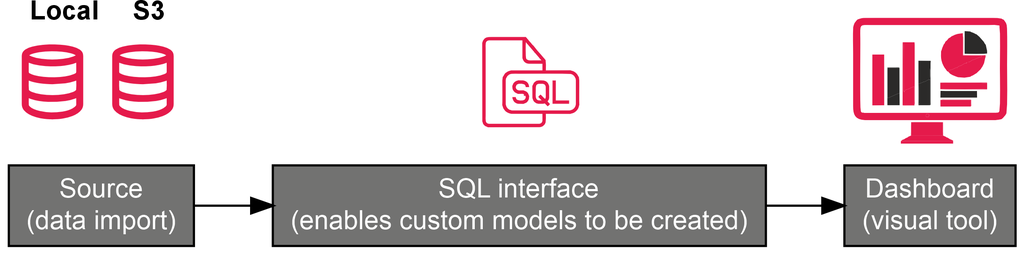

## Demo

- Making sense of Case and other source \(\rightarrow\) Let’s check it out!
- http://localhost:9009/
- We will look at how to use Rill to explore project data and how we can use our relational data table to 1) determine project overlap and difference across different data sources; and 2) quickly visualize select features using basic time-series tools.